# Myanmar’s changing conflict geography

January 2021–September 2025 · Take-home Exercise 2

Yufan You

## Contents

Study question and evidence  
Clusters and changes over time  
Redistribution, uncertainty and peacebuilding implications

## Research question and study design

**Where is recorded armed conflict concentrated, and where is that concentration changing?**

- 53,899 events in 330 Myanmar townships, January 2021–September 2025.
- Battles, explosions/remote violence and violence against civilians.
- Local Moran’s I and Gi* for spatial patterns. Quarterly Gi* and Mann–Kendall for change.
- 327 townships in spatial tests. Three islands remain in descriptive counts.

ACLED records reported events. Counts measure recorded burden and concentration.

Sources: ACLED course file, accessed 8 Oct 2026; MIMU township boundaries v9.4. Original sample: 87,109 rows.

## Monthly frequency and severity

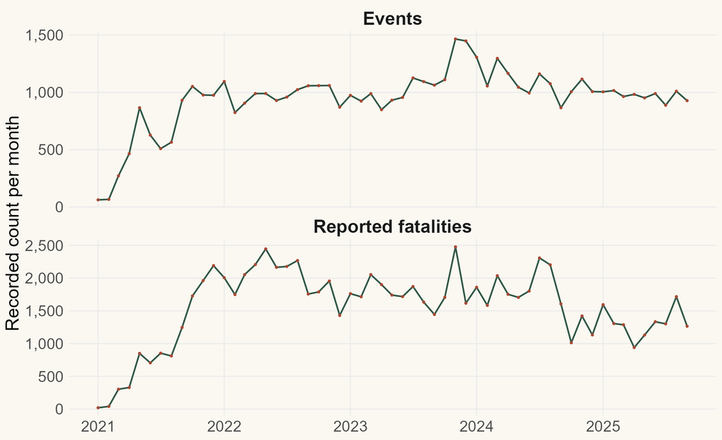

The peak is 1,466 events in November 2023. Event frequency and reported fatalities follow different paths.

## The recorded burden is uneven

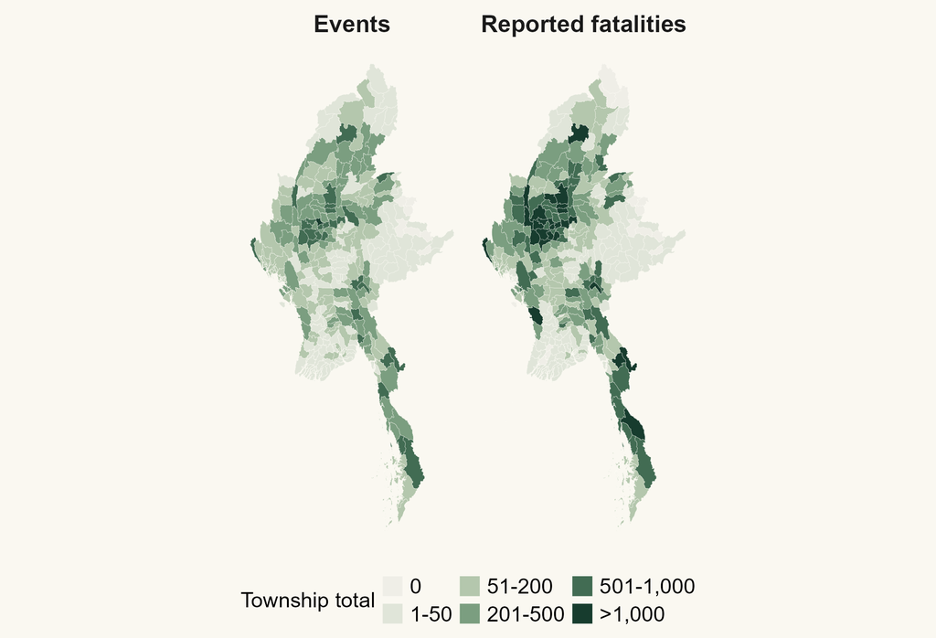

**Monywa** has the most events: **1,039**.

The ten largest township totals account for **15.9%** of recorded events.

**Kale** leads in reported fatalities.

The maps use identical count bands. Neither includes a population denominator.

## Clusters and spatial outliers

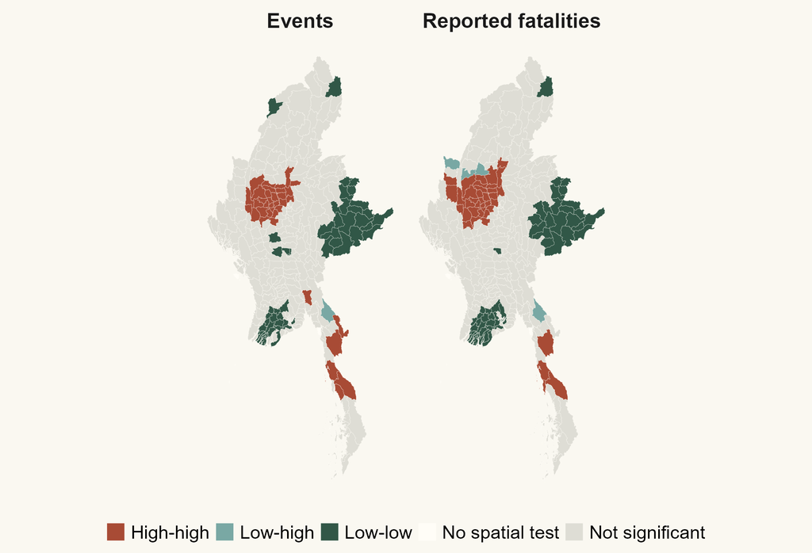

Event counts show **36 high-high** townships.

**1 low-high** outliers have lower counts beside higher-count neighbours.

Global Moran’s I = **0.488**, permutation p = **0.001**.

Primary colours require two-sided p < .05. Multiple-testing adjustment reduces the number of flags.

## Gi* identifies concentrated neighbourhoods

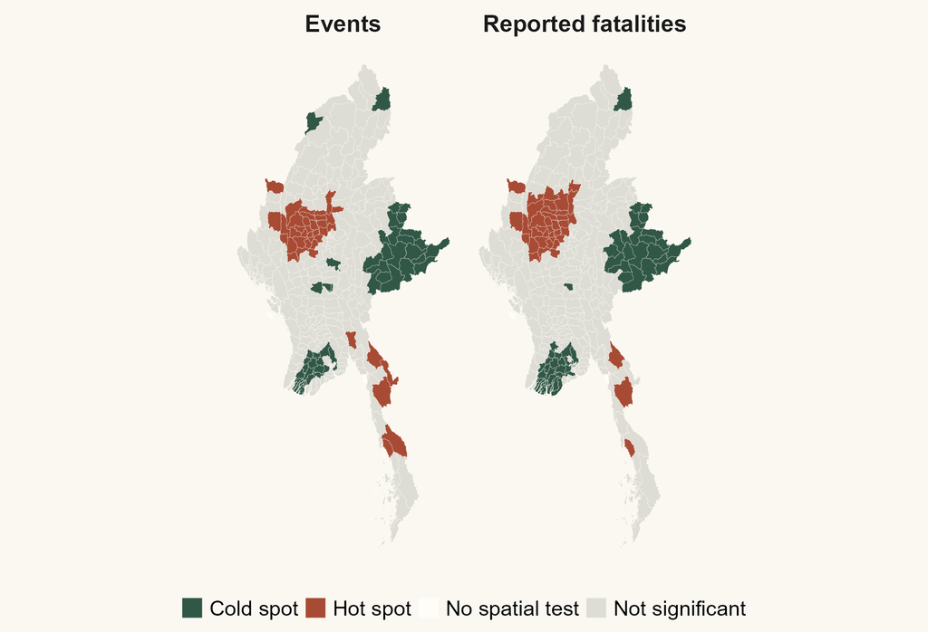

**39 event hot spots** and **51 cold spots** at p < .05.

Gi* includes the focal township and its neighbours.

Fatalities reveal a related but different burden pattern.

Low recorded activity needs local verification before any safety interpretation.

## Emerging patterns over 19 quarters

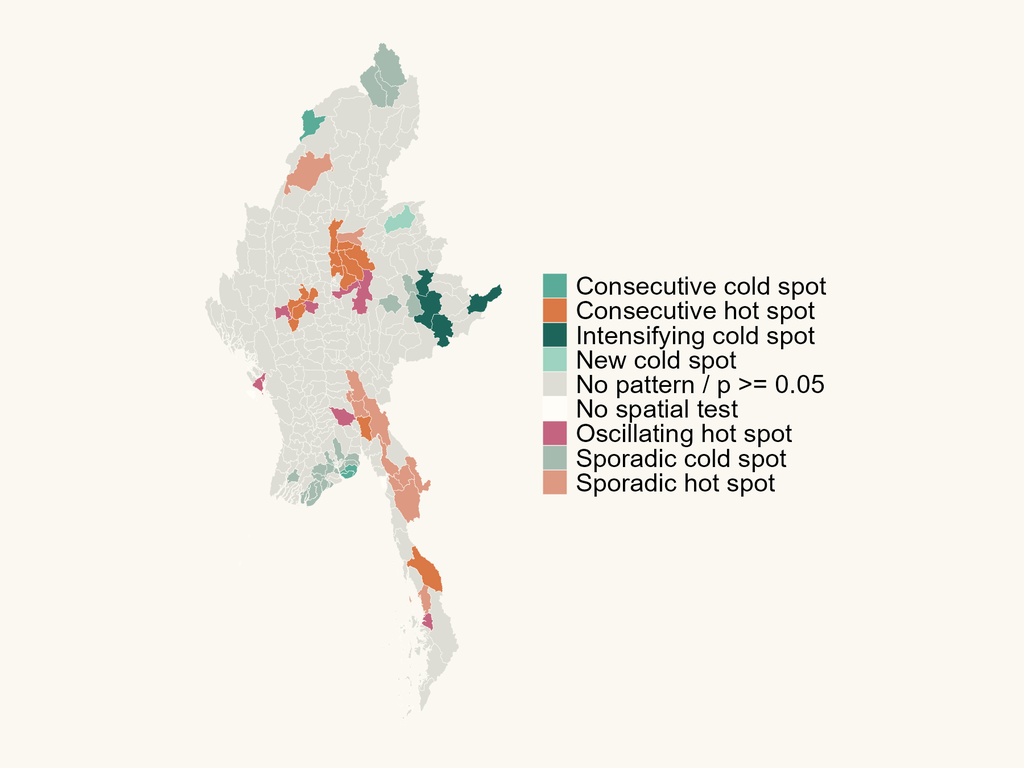

**165** townships have Mann–Kendall p < .05. **150** remain after BH adjustment.

Gi* uses current and previous-quarter neighbours against a fixed space-time reference.

The map filters for significant trends. Persistent classes without a significant trend remain in the report’s results table.

## The trajectories explain the labels

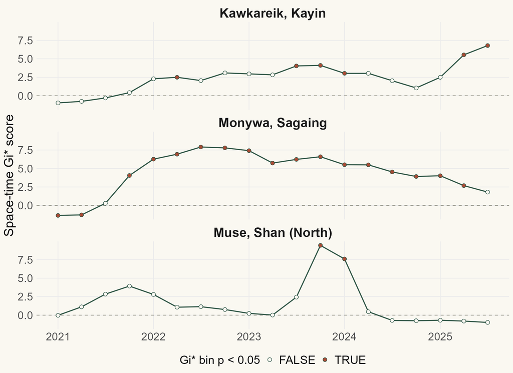

Cases include the largest burden, the largest increasing final hot spot, and the largest declining concentration.

Filled points have Gi* bin p < .05.

A declining concentration can coexist with a substantial accumulated burden. A class label compresses a more complicated history.

## Precision and dependence affect confidence

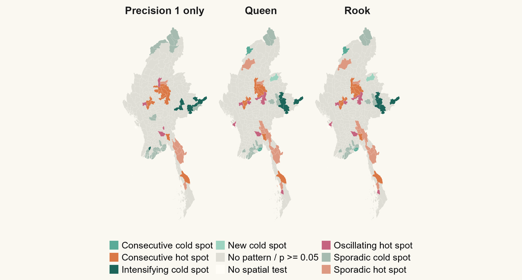

Class agreement: Queen/rook **100%**; main/precision 1 only **80.1%**. Short-block trend checks give 129 and 114 p < .05 results, versus 165 for ordinary MK.

## A spatial scan isolates redistribution

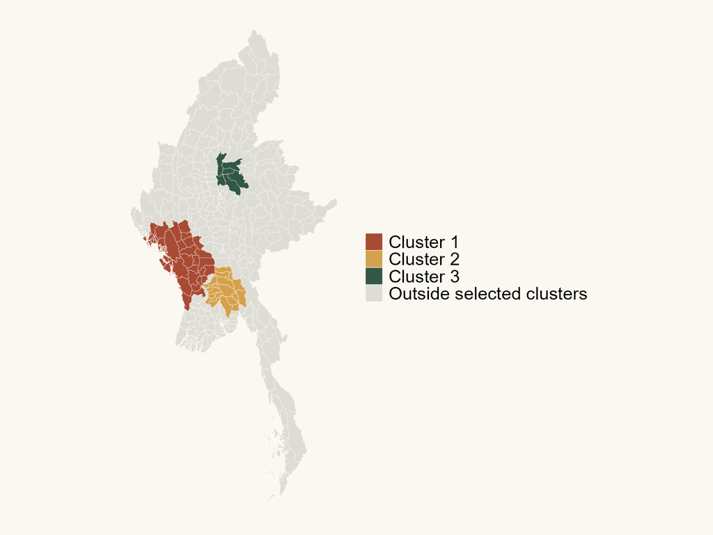

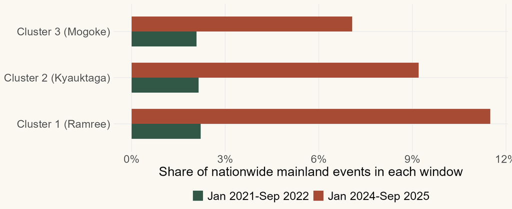

The leading cluster around **Ramree** increases its national share from **2.2% to 11.5%**.

Search-adjusted p = **0.001**. Equal 21-month windows control duration and calendar-month composition.

## Peacebuilding implications and limits

Sustained high-burden areas support maintaining humanitarian capacity. Increasing concentrations and spatial outliers suggest where local verification may be useful.

Allocation decisions also need displacement, service capacity and access information. Reporting gaps, uncertain locations and related conflict events limit statistical confidence.

The scan identifies a shift in recorded geography. Its clusters are exploratory and do not define front lines or predict the next incident.

Use the maps to guide questions for local partners and needs assessments.

Technical report and complete methods · [Reproducible GitHub project](https://github.com/yufanyou2025/ISS626-VAA/tree/master/Take-home_Ex/Take-home_Ex02)